# Supplementary Code: Pervasive changes of mRNA splicing in upf1 deficient zebrafish identify rpl10a as a regulator of T cell development

Divine-Fondzenyuy Lawir, Katarzyna Sikora, Connor O´Meara, Michael Schorpp, and Thomas Boehm

8/30/2019

## **Summary**

This document provides the R code and accompanying explanations to reproduce Figures 2A-D, 3B-C,F, 4A-D, 5C from the manuscript with working title “Pervasive changes of mRNA splicing in upf1 deficient zebrafish identify rpl10a as a regulator of T cell development”" by Lawir et al.. The analysis starts with sleuth (differential transcript expression) and salmon (transcript quantitation), as well as rMATS (differential splicing) output tables and walks the reader through the computational procedures underlying the manuscript figures. A copy of this document will be deposited on GitHub under https://github.com/katsikora/Lawir2019_SupplementaryCodeAndData upon publication. The code is formatted in a way to facilitate understanding and interpretation by a lay R user. This code is authored by Katarzyna Sikora.

#### Input data

Input data (TPM transcript counts and differential transcript expression results, as well as differential splicing analysis results) can be obtained under:

- https://owncloud.gwdg.de/index.php/s/lE5jNBwMZvZq8ZU/download (upf1 transcript expression table with TPM from salmon, RData format)
- https://owncloud.gwdg.de/index.php/s/tEawWxhokEvnYXB/download (upf1 differential transcript expression results from sleuth, txt format)
- https://owncloud.gwdg.de/index.php/s/EaqmwLATYmOiMhw/download (tnpo3 transcript expression table with TPM from salmon, RData format)
- https://owncloud.gwdg.de/index.php/s/bnbFKnUJzSrN1SA/download (tnpo3 differential transcript expression results from sleuth, txt format)
- https://owncloud.gwdg.de/index.php/s/4MXxMNkLIim6zqV/download (upf1 summary of differential transcript results from rMATS, txt format)
- https://owncloud.gwdg.de/index.php/s/GYs9TZ0NojfkC8n/download (upf1 alternative 3’ splice site events from rMATS, txt format)
- https://owncloud.gwdg.de/index.php/s/PG6gMPMxR8kj4Tc/download (upf1 alternative 5’ splice site events from rMATS, txt format)
- https://owncloud.gwdg.de/index.php/s/aI1rMW7mluqmGCW/download (upf1 mutually exclusive exon events from rMATS, txt format)
- https://owncloud.gwdg.de/index.php/s/TTtonDyto0wysRr/download (upf1 intron retention events from rMATS, txt format)
- https://owncloud.gwdg.de/index.php/s/ToesC9NBDAGKmkE/download (upf1 exon skipping events from rMATS, txt format)
- https://owncloud.gwdg.de/index.php/s/fDsyi2bm2hyCwqm/download (tnpo3 summary of differential transcript results from rMATS, txt format)
- https://owncloud.gwdg.de/index.php/s/iuKZhNHtnA6xRqi/download (tnpo3 alternative 3’ splice site events from rMATS, txt format)
- https://owncloud.gwdg.de/index.php/s/ZZ1uwNHxQ7Aiydy/download (tnpo3 alternative 5’ splice site events from rMATS, txt format)
- https://owncloud.gwdg.de/index.php/s/8qOyBxHs4Sldj3W/download (tnpo3 mutually exclusive exon events from rMATS, txt format)
- https://owncloud.gwdg.de/index.php/s/KDc9m65IRwEUlKd/download (tnpo3 intron retention events from rMATS, txt format)
- https://owncloud.gwdg.de/index.php/s/BipXuUaEOfsq3tp/download (tnpo3 exon skipping events from rMATS, txt format)

Transcripts are identified by ensembl transcript id, release 83.

#### Load required packages

```r
library(data.table, quietly = TRUE)
library(dplyr, quietly = TRUE)
library(reshape2, quietly = TRUE)
```

```r
library(ggplot2, quietly = TRUE)
library(magrittr, quietly = TRUE)
library(limma, quietly = TRUE)
library(car, quietly = TRUE)
library(curl, quietly = TRUE)
library(biomaRt, quietly = TRUE)
library(gridExtra, quietly = TRUE)
library(cowplot, quietly = TRUE)
library(VennDiagram, quietly = TRUE)
```

#### Figures 2A-D: Transcript level quantitation in upf1 mutant and wildtype fish with biotype annotation

Load salmon output data with transcript-level TPM counts for upf1 mutant and wildtype fish:

```r
con <- curl("https://owncloud.gwdg.de/index.php/s/lE5jNBwMZvZq8ZU/download",
    open = "rb")
load(con)
close(con)

dim(qdat)
```

```
## [1] 461240      4
```

```r
sum(complete.cases(qdat))
```

```
## [1] 461240
```

```r
## qdat is in a data.table format - make sure the data.table package is
## loaded!
qdat
```

```
##                       Name       TPM   SampleID Group
##      1: ENSDART00000164359 332.12000 HJ028_Mut1   Mut
##      2: ENSDART00000157701   2.22722 HJ028_Mut1   Mut
##      3: ENSDART00000158290   1.41980 HJ028_Mut1   Mut
##      4: ENSDART00000167898 978.31300 HJ028_Mut1   Mut
##      5: ENSDART00000166393   7.20239 HJ028_Mut1   Mut
##     ---
## 461236: ENSDART00000166187   3.10497  HJ028_WT4    WT
## 461237: ENSDART00000168512   5.20247  HJ028_WT4    WT
## 461238: ENSDART00000171223  17.83250  HJ028_WT4    WT
## 461239: ENSDART00000163136  19.98070  HJ028_WT4    WT
## 461240: ENSDART00000165750  12.01640  HJ028_WT4    WT
```

Load sleuth output data with results of differential transcript expression for upf1 mutant and wildtype fish:

```r
con <- curl("https://owncloud.gwdg.de/index.php/s/tEawWxhokEvnYXB/download",
    open = "r")
results_table <- read.table(con, sep = "\t", header = TRUE, quote = "", as.is = TRUE)
close(con)

dim(results_table)
```

```
## [1] 57655    13
```

```r
sum(complete.cases(results_table))
```

```
## [1] 44587
```

```r
results_table <- results_table[complete.cases(results_table), ]
dim(results_table)
```

```
## [1] 44587    13
```

```r
head(results_table)
```

```
##            target_id test_stat         pval         qval      rss
## 1 ENSDART00000147048  47.28836 6.127507e-12 2.732072e-07 27.82941
## 2 ENSDART00000149400  44.20215 2.961561e-11 4.659106e-07 34.19818
## 3 ENSDART00000146847  44.09084 3.134841e-11 4.659106e-07 10.57485
## 4 ENSDART00000136871  43.02349 5.408649e-11 6.028886e-07 26.81887
## 5 ENSDART00000164135  42.22610 8.130753e-11 7.250518e-07 73.61602
## 6 ENSDART00000165314  41.66921 1.080979e-10 8.032935e-07 25.11587
##    sigma_sq     tech_var mean_obs   var_obs sigma_sq_pmax smooth_sigma_sq
## 1  3.975066 0.0005633779 9.294320  3.975630      3.975066      0.02010536
## 2  4.877914 0.0075407346 8.230889  4.885455      4.877914      0.02013055
## 3  1.510267 0.0004255516 8.760180  1.510693      1.510267      0.01949746
## 4  3.828279 0.0029890250 7.921034  3.831268      3.828279      0.02111328
## 5 10.510789 0.0057849308 3.764295 10.516574     10.510789      0.14247180
## 6  3.587544 0.0004369969 9.278983  3.587981      3.587544      0.02007007
##   final_sigma_sq degrees_free
## 1       3.975066            1
## 2       4.877914            1
## 3       1.510267            1
## 4       3.828279            1
## 5      10.510789            1
## 6       3.587544            1
```

Annotate the ‘results_table’ with mean TPM values per group using ‘qdat’ and calculate log2 fold changes:

```r
meandat <- summarize(group_by(qdat, Name, Group), MeanTPM = mean(TPM))
meandatW <- dcast(Name ~ Group, value.var = "MeanTPM", data = meandat)

results_table$MeanTPM.WT <- meandatW$WT[match(results_table$target_id, meandatW$Name)]
results_table$MeanTPM.Mut <- meandatW$Mut[match(results_table$target_id, meandatW$Name)]
results_table$Log2FC <- with(results_table, log2(MeanTPM.Mut/MeanTPM.WT))
sum(is.infinite(results_table$Log2FC))
```

```
## [1] 5
```

We have calculated log2 fold changes on mean TPM values without adding a pseudocount, using only transcripts for which sleuth produced differential expression estimates. This conservative approach doesn’t introduce additional noise when calculating log2 fold changes for lowly expressed genes. As a result, 5 values are infinite, and we will ignore those for further analysis.

Filter results table to retain transcripts with statistical support for differential expression passing the filtering criteria of absolute log2 fold change at least 1, and qvalue less than 0.05:

```r
results_table.filt <- results_table[results_table$qval < 0.05 & abs(results_table$Log2FC) >=
    1, ]
results_table.filt <- results_table.filt[complete.cases(results_table.filt),
    ]
dim(results_table.filt)
```

```
## [1] 1588   16
```

This manuscript focuses on the contrast in regulation of NMD and non-NMD transcripts, as defined in ensembl gene annotation http://vega.archive.ensembl.org/info/about/gene_and_transcript_types.html .  
Results reported in the manuscript were annotated using ensembl release 88. Annotate filtered results with transcript biotype using the biomaRt package:

```r
zv10.ens <- useMart(biomart = "ensembl", dataset = "drerio_gene_ensembl", host = "http://mar2017.archive.ensembl.org")
bmk <- getBM(attributes = c("ensembl_transcript_id", "transcript_biotype", "ensembl_gene_id",
    "external_gene_name"), filter = "ensembl_transcript_id", values = results_table.filt$target_id,
    mart = zv10.ens)
res.tab.filt.an <- merge(x = results_table.filt, y = bmk, by.x = "target_id",
    by.y = "ensembl_transcript_id", all.x = TRUE)
head(res.tab.filt.an)
```

```
##            target_id test_stat         pval        qval        rss
## 1 ENSDART00000001359  8.864949 2.906984e-03 0.046910502 22.9576331
## 2 ENSDART00000002055 18.884653 1.388654e-05 0.001261017  0.6377130
## 3 ENSDART00000002242 15.258091 9.377419e-05 0.004936375  4.9311239
## 4 ENSDART00000002318 17.252492 3.272681e-05 0.002319857  1.8128961
## 5 ENSDART00000002510 10.665155 1.091727e-03 0.025605908  0.8558127
## 6 ENSDART00000002568 18.532856 1.670005e-05 0.001431933  0.8640028
##     sigma_sq     tech_var mean_obs    var_obs sigma_sq_pmax
## 1 3.23441670 0.0452451670 2.044700 3.27966186    3.23441670
## 2 0.09029646 0.0008054025 7.843766 0.09110186    0.09029646
## 3 0.70042109 0.0040251815 5.922203 0.70444628    0.70042109
## 4 0.25886561 0.0001195459 9.472892 0.25898516    0.25886561
## 5 0.11633118 0.0059277785 5.316839 0.12225896    0.11633118
## 6 0.12200909 0.0014198871 6.909399 0.12342898    0.12200909
##   smooth_sigma_sq final_sigma_sq degrees_free MeanTPM.WT MeanTPM.Mut
## 1      0.38467017     3.23441670            1  0.5638108   0.0727835
## 2      0.02146556     0.09029646            1  5.9119025  11.8447750
## 3      0.04809614     0.70042109            1  8.3743950   2.1831150
## 4      0.02059790     0.25886561            1 45.8223750 129.6968500
## 5      0.06532331     0.11633118            1  0.8279787   1.7381750
## 6      0.02966933     0.12200909            1  4.3003875   9.4197275
##      Log2FC transcript_biotype    ensembl_gene_id external_gene_name
## 1 -2.953528     protein_coding ENSDARG00000031885             psmb12
## 2  1.002556     protein_coding ENSDARG00000078760           cacna2d3
## 3 -1.939597     protein_coding ENSDARG00000095751          zgc:77778
## 4  1.501019     protein_coding ENSDARG00000016783             srsf6b
## 5  1.069908     protein_coding ENSDARG00000014545            golim4b
## 6  1.131219     protein_coding ENSDARG00000010035             engase
```

Annotate ‘qdat’ TPM expression table with transcript biotype information from ensembl:

```r
bmk2 <- getBM(attributes = c("ensembl_transcript_id", "transcript_biotype",
    "ensembl_gene_id", "external_gene_name"), filter = "ensembl_transcript_id",
    values = qdat$Name, mart = zv10.ens)
qdat.an <- unique(merge(x = qdat, y = bmk2, by.x = "Name", by.y = "ensembl_transcript_id",
    all.x = TRUE, allow.cartesian = TRUE))

qdat.an$Biotype2 <- "nonNMD"
qdat.an$Biotype2[qdat.an$transcript_biotype %in% "nonsense_mediated_decay"] <- "NMD"
head(qdat.an)
```

```
##                  Name     TPM   SampleID Group transcript_biotype
## 1: ENSDART00000000004 3.65016 HJ028_Mut1   Mut     protein_coding
## 2: ENSDART00000000004 3.54777 HJ028_Mut2   Mut     protein_coding
## 3: ENSDART00000000004 3.18396 HJ028_Mut3   Mut     protein_coding
## 4: ENSDART00000000004 3.14517 HJ028_Mut4   Mut     protein_coding
## 5: ENSDART00000000004 2.47270  HJ028_WT1    WT     protein_coding
## 6: ENSDART00000000004 2.62164  HJ028_WT2    WT     protein_coding
##       ensembl_gene_id external_gene_name Biotype2
## 1: ENSDARG00000000001            slc35a5   nonNMD
## 2: ENSDARG00000000001            slc35a5   nonNMD
## 3: ENSDARG00000000001            slc35a5   nonNMD
## 4: ENSDARG00000000001            slc35a5   nonNMD
## 5: ENSDARG00000000001            slc35a5   nonNMD
## 6: ENSDARG00000000001            slc35a5   nonNMD
```

We collapse all transcript isoforms not annotated as “nonsense_mediated_decay” to one category “nonNMD”.

Calculate mean transript expression over replicates in each group and add binarized transcript biotype information:

```r
TPMmean <- as.data.frame(summarize(group_by(qdat.an, Group, Name), MeanTPM = mean(TPM)),
    stringsAsFactors = FALSE)
TPMmean$Biotype <- qdat.an$Biotype2[match(TPMmean$Name, qdat.an$Name)]
head(TPMmean)
```

```
##   Group               Name    MeanTPM Biotype
## 1   Mut ENSDART00000000004  3.3817650  nonNMD
## 2   Mut ENSDART00000000005  9.7090225  nonNMD
## 3   Mut ENSDART00000000042  0.4087811  nonNMD
## 4   Mut ENSDART00000000069 35.2466500  nonNMD
## 5   Mut ENSDART00000000070 45.0999250  nonNMD
## 6   Mut ENSDART00000000087  6.3814425  nonNMD
```

Reshape table to obtain separate columns for the WT and for the Mut group. Add information on passing statistical filters:

```r
TPMmean2 <- dcast(Name + Biotype ~ Group, data = TPMmean, value.var = "MeanTPM")
TPMmean2$Filter <- "Fail"
TPMmean2$Filter[TPMmean2$Name %in% results_table.filt$target_id] <- "Pass"
head(TPMmean2)
```

```
##                 Name Biotype        Mut         WT Filter
## 1 ENSDART00000000004  nonNMD  3.3817650  2.8215250   Fail
## 2 ENSDART00000000005  nonNMD  9.7090225  8.8745625   Fail
## 3 ENSDART00000000042  nonNMD  0.4087811  0.0947444   Fail
## 4 ENSDART00000000069  nonNMD 35.2466500 44.5662250   Fail
## 5 ENSDART00000000070  nonNMD 45.0999250 38.8842000   Fail
## 6 ENSDART00000000087  nonNMD  6.3814425  5.4495375   Fail
```

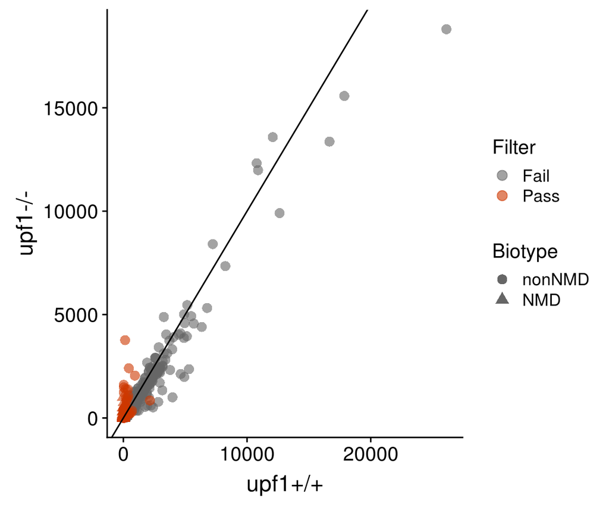

Figure 2A

```r
TPMmean2$Biotype <- factor(TPMmean2$Biotype, levels = c("nonNMD", "NMD"))
TPMmean2$Filter <- factor(TPMmean2$Filter, levels = c("Fail", "Pass"))
ggplot(TPMmean2 %>% arrange(Filter)) + geom_point(aes(x = WT, y = Mut, colour = Filter,
    shape = Biotype), size = 3, alpha = 0.6) + geom_abline(aes(intercept = 0,
    slope = 1)) + theme(axis.text = element_text(size = 14), axis.title = element_text(size = 16),
    strip.text = element_text(size = 12)) + scale_colour_manual(values = c("grey40",
    "orangered3")) + xlab("upf1+/+") + ylab("upf1-/-")
```

Tabulate number of up- and down-regulated transcripts passing the filters in “NMD” and “nonNMD” categories:

```r
res.tab.filt.an$ChangeDirection <- "UP"
res.tab.filt.an$ChangeDirection[res.tab.filt.an$Log2FC < 0] <- "DOWN"
res.tab.filt.an$Biotype2 <- "nonNMD"
res.tab.filt.an$Biotype2[res.tab.filt.an$transcript_biotype %in% "nonsense_mediated_decay"] <- "NMD"
table(res.tab.filt.an$Biotype2, res.tab.filt.an$ChangeDirection)
```

```
##
##          DOWN   UP
##   NMD       2  119
##   nonNMD  231 1236
```

Replot Figure 2A setting axis limits to 2000 TPM and labelling a few genes of interest:

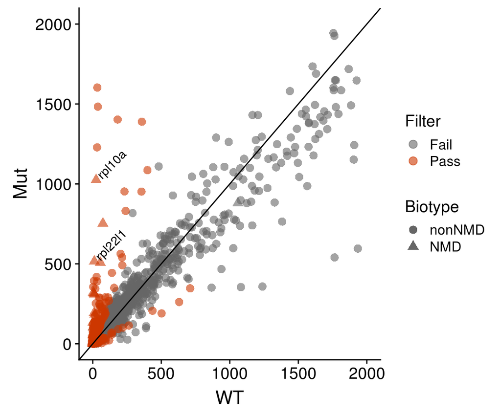

Figure 2B

```r
auxtab <- TPMmean2[TPMmean2$Biotype %in% "NMD" & TPMmean2$WT < 200 & TPMmean2$Mut >
    450, ]
auxtab$Symbol <- bmk$external_gene_name[match(auxtab$Name, bmk$ensembl_transcript_id)]
auxtab <- auxtab[!auxtab$Symbol %in% "si:ch211-196l7.4", ]
ggplot(TPMmean2 %>% arrange(Filter)) + geom_point(aes(x = WT, y = Mut, colour = Filter,
    shape = Biotype), size = 3, alpha = 0.6) + geom_abline(aes(intercept = 0,
    slope = 1)) + geom_text(data = auxtab, aes(x = WT, y = Mut, label = Symbol),
    hjust = 0, nudge_x = 20, nudge_y = 20, angle = 45) + theme(axis.text = element_text(size = 14),
    axis.title = element_text(size = 16), strip.text = element_text(size = 12)) +
    xlim(0, 2000) + ylim(0, 2000) + scale_colour_manual(values = c("grey40",
    "orangered3"))
```

Aggregate TPM counts per gene as sum over transcript counts, separately for “NMD” and for “nonNMD” transcript classes:

```r
qdat.sum <- summarize(group_by(qdat.an, ensembl_gene_id, SampleID, Biotype2),
    sumTPM = sum(TPM))
qdat.sumW <- dcast(ensembl_gene_id + SampleID ~ Biotype2, value.var = "sumTPM",
    data = qdat.sum)
qdat.sumW <- qdat.sumW[complete.cases(qdat.sumW), ]
dim(qdat.sumW)
```

```
## [1] 4736    4
```

```r
head(qdat.sumW)
```

```
##        ensembl_gene_id   SampleID      NMD  nonNMD
## 393 ENSDARG00000000747 HJ028_Mut1 0.296213 3.90615
## 394 ENSDARG00000000747 HJ028_Mut2 0.636830 2.57686
## 395 ENSDARG00000000747 HJ028_Mut3 0.351156 3.10285
## 396 ENSDARG00000000747 HJ028_Mut4 0.393493 2.73254
## 397 ENSDARG00000000747  HJ028_WT1 0.312446 1.63519
## 398 ENSDARG00000000747  HJ028_WT2 0.101204 1.62504
```

Calculate mean fraction of “NMD” transcript expression against sum of “NMD” and “nonNMD” transcript expression per gene (“NMD ratio”):

```r
qdat.sumW$Ratio <- with(qdat.sumW, NMD/(NMD + nonNMD))
qdat.sumW$Group <- gsub("[0-9]", "", gsub("HJ.+_", "", qdat.sumW$SampleID))
upf1_qdat.sumW <- qdat.sumW
qdat.sum2 <- summarize(group_by(qdat.sumW, ensembl_gene_id, Group), MeanRatio = mean(Ratio))
qdat.sum2W <- dcast(ensembl_gene_id ~ Group, value.var = "MeanRatio", data = qdat.sum2)
dim(qdat.sum2W)
```

```
## [1] 592   3
```

```r
head(qdat.sum2W)
```

```
##      ensembl_gene_id         Mut          WT
## 1 ENSDARG00000000747 0.124047827 0.120655092
## 2 ENSDARG00000001169 0.093232363 0.198733315
## 3 ENSDARG00000001244 0.208995985 0.053846760
## 4 ENSDARG00000002487 0.024106822 0.020831720
## 5 ENSDARG00000002549 0.147229810 0.087934160
## 6 ENSDARG00000002710 0.001308281 0.001599692
```

Apply limma to logit-transformed NMD ratios to obtain a list of statistically different ratios between mutant and wildtype fish, and filter results for FDR<0.05:

```r
qdat.sumW$LogitRatio <- logit(qdat.sumW$Ratio, percents = FALSE, adjust = 0.025)

limdat <- dcast(ensembl_gene_id ~ SampleID, value.var = "LogitRatio", data = qdat.sumW)
rownames(limdat) <- limdat$ensembl_gene_id
limdat <- limdat[, !colnames(limdat) %in% "ensembl_gene_id"]

sampleInfo <- unique(qdat.sumW[, c("SampleID", "Group")])
rownames(sampleInfo) <- sampleInfo$SampleID
sampleInfo <- sampleInfo[match(colnames(limdat), sampleInfo$SampleID), ]

# limma
design <- as.data.frame(matrix(ncol = 2, nrow = (ncol(limdat))), stringsAsFactors = FALSE)
colnames(design) <- c("Intercept", "Group")
rownames(design) <- colnames(limdat)
design$Group <- as.numeric(factor(sampleInfo$Group[match(colnames(limdat), sampleInfo$SampleID)],
    levels = c("WT", "Mut")))

design$Intercept <- 1
design <- as.matrix(design)

fit <- lmFit(limdat, design)
fit.eB <- eBayes(fit)
tT.FDR5 <- topTable(fit.eB, 2, p.value = 0.05, number = Inf)[, c("logFC", "t",
    "adj.P.Val", "B")]
dim(tT.FDR5)
```

```
## [1] 115   4
```

```r
head(tT.FDR5)
```

```
##                       logFC        t    adj.P.Val        B
## ENSDARG00000042905 2.477086 64.41126 1.571264e-08 16.18805
## ENSDARG00000029818 3.352589 63.44326 1.571264e-08 16.09776
## ENSDARG00000014244 2.206253 42.48811 1.465112e-07 13.48717
## ENSDARG00000010244 3.443351 41.88633 1.465112e-07 13.38778
## ENSDARG00000007863 1.556780 37.41147 2.595315e-07 12.58859
## ENSDARG00000035325 1.591192 31.23673 7.384495e-07 11.27544
```

Add information on passing or failing filters on statistical metrics:

```r
qdat.sum2W$Filter <- "FAIL"
qdat.sum2W$Filter[qdat.sum2W$ensembl_gene_id %in% rownames(tT.FDR5)] <- "PASS"
table(qdat.sum2W$Filter)
```

```
##
## FAIL PASS
##  477  115
```

Plot NMD ratios per gene aggregated over wild type and mutant groups:

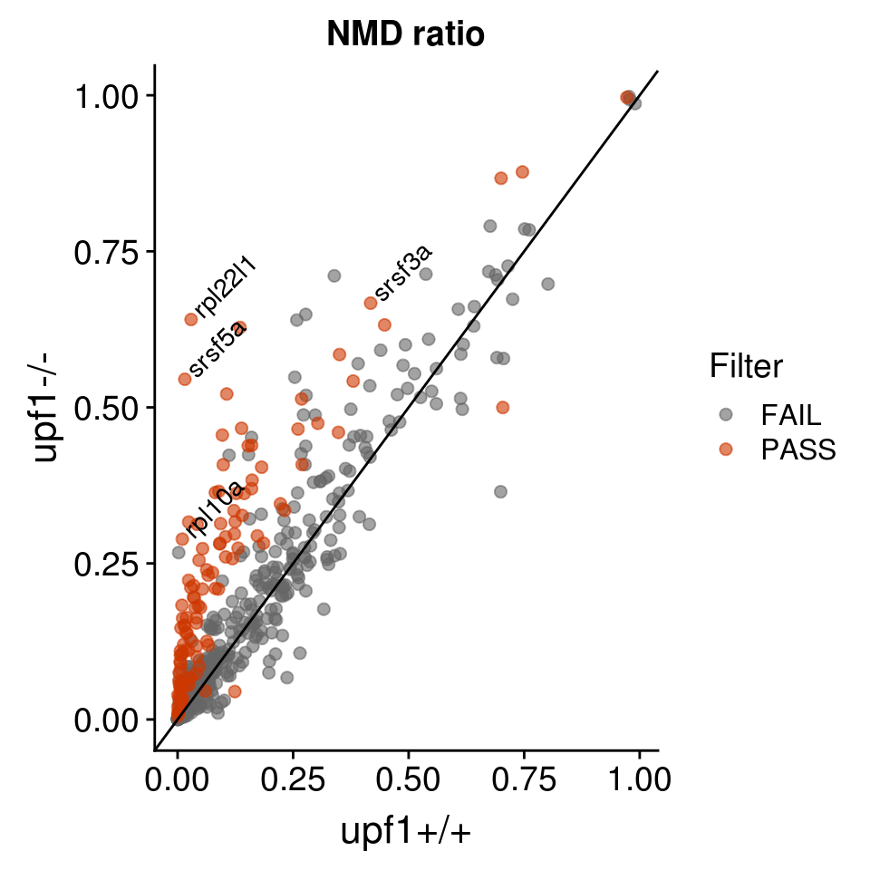

Figure 2C

```r
auxtab <- qdat.sum2W[qdat.sum2W$ensembl_gene_id %in% bmk$ensembl_gene_id[bmk$external_gene_name %in%
    c("rpl22l1", "rpl10a", "srsf5a", "srsf3a")], ]
auxtab$Symbol <- bmk$external_gene_name[match(auxtab$ensembl_gene_id, bmk$ensembl_gene_id)]
ggplot(qdat.sum2W %>% arrange(Filter)) + geom_point(aes(x = WT, y = Mut, colour = Filter),
    size = 2, alpha = 0.6) + geom_abline(aes(intercept = 0, slope = 1)) + scale_colour_manual(values = c("grey40",
    "orangered3")) + geom_text(data = auxtab, aes(x = WT, y = Mut, label = Symbol),
    hjust = 0, nudge_x = 0.01, nudge_y = 0.01, angle = 45) + theme(axis.text = element_text(size = 14),
    axis.title = element_text(size = 16), strip.text = element_text(size = 12)) +
    ggtitle("NMD ratio") + xlab("upf1+/+") + ylab("upf1-/-")
```

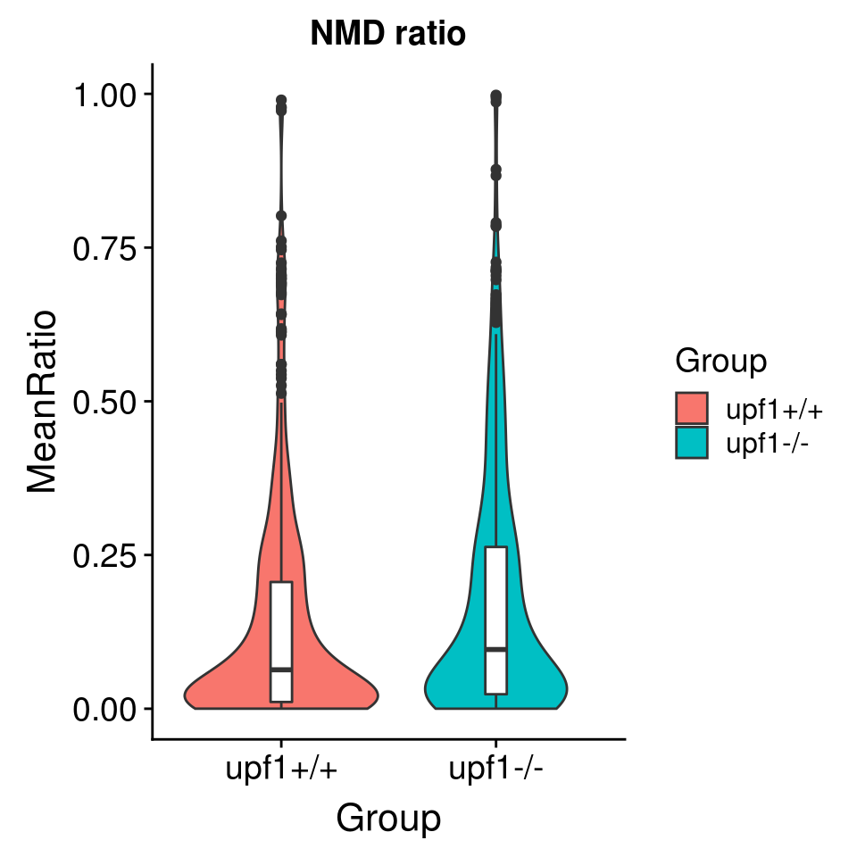

Figure 2D

```r
qdat.sum2$Group[qdat.sum2$Group %in% "WT"] <- "upf1+/+"
qdat.sum2$Group[qdat.sum2$Group %in% "Mut"] <- "upf1-/-"
qdat.sum2$Group <- factor(qdat.sum2$Group, levels = c("upf1+/+", "upf1-/-"))
ggplot(data = qdat.sum2) + geom_violin(aes(x = Group, y = MeanRatio, fill = Group)) +
    geom_boxplot(aes(x = Group, y = MeanRatio), width = 0.1) + ggtitle("NMD ratio") +
    theme(axis.text = element_text(size = 14), axis.title = element_text(size = 16))
```

#### Figure 3B: Differential splicing event detection in upf1 mutant and wildtype fish

Download event tables, one for each alternative event class (SE, RI, MXE, A5SS, A3SS), and filter for FDR<0.01 and absolute inclusion level difference of 0.05:

```r
asv <- c("A3SS", "A5SS", "MXE", "RI", "SE")
resL <- vector("list", length(asv))
names(resL) <- asv
conL <- list("https://owncloud.gwdg.de/index.php/s/GYs9TZ0NojfkC8n/download",
    "https://owncloud.gwdg.de/index.php/s/PG6gMPMxR8kj4Tc/download", "https://owncloud.gwdg.de/index.php/s/aI1rMW7mluqmGCW/download",
    "https://owncloud.gwdg.de/index.php/s/TTtonDyto0wysRr/download", "https://owncloud.gwdg.de/index.php/s/ToesC9NBDAGKmkE/download")
names(conL) <- asv

for (i in seq_along(asv)) {
    con <- curl(conL[[i]], open = "r")
    tabi <- read.table(con, sep = "\t", header = TRUE, quote = "", as.is = TRUE)
    close(con)
    tabi$GeneID <- with(tabi, gsub("\"", "", GeneID))
    tabi$geneSymbol <- with(tabi, gsub("\"", "", geneSymbol))
    tabi_f <- tabi[tabi$FDR < 0.01 & abs(tabi$IncLevelDifference) >= 0.05, ]
    resL[[i]] <- tabi_f
}
unlist(lapply(resL, function(X) nrow(X)))
```

```
## A3SS A5SS  MXE   RI   SE
##   76   47  198   62 1782
```

```r
unlist(lapply(resL, function(X) length(unique(X$GeneID))))
```

```
## A3SS A5SS  MXE   RI   SE
##   74   47  161   48 1463
```

```r
upf1_resL <- resL
```

Download the summary table for rMATS events :

```r
con <- curl("https://owncloud.gwdg.de/index.php/s/4MXxMNkLIim6zqV/download",
    open = "r")
sumtab <- read.table(con, sep = "\t", header = TRUE, quote = "", as.is = TRUE)
close(con)
sumtab
```

```
##   EventType NumEvents.JC.only SigEvents.JC.only NumEvents.JC.readsOnTarget
## 1        SE             30752   2702 (383:2319)                      30851
## 2       MXE              4366     321 (163:158)                       4378
## 3      A5SS               668        85 (51:34)                        669
## 4      A3SS              1271       130 (67:63)                       1272
## 5        RI               711       102 (39:63)                        718
##   SigEvents.JC.readsOnTarget
## 1            2697 (385:2312)
## 2              232 (121:111)
## 3                 93 (57:36)
## 4                132 (67:65)
## 5                115 (44:71)
```

Update information using event counts from tables filtered according to chosen criteria and format for plotting:

```r
asvo <- c("SE", "RI", "MXE", "A5SS", "A3SS")
sumtab <- sumtab[match(c(asvo), sumtab$EventType), ]
sumtab$LYlab <- c("Skipped Exon", "Retained Intron", "Mutually Exclusive Exons",
    "Alternative Donor Site", "Alternative Acceptor Site")
sumtab$RYlab <- sumtab$NumEvents.JC.only
sumtab$WT <- NA
sumtab$MT <- NA
for (k in seq_along(asvo)) {
    tab.filt <- resL[[asvo[k]]]
    # at first, keep the same direction as in the original rMATS ouput
    sumtab$WT[sumtab$EventType == asvo[k]] <- nrow(tab.filt[tab.filt$IncLevelDifference <
        0, ])
    sumtab$MT[sumtab$EventType == asvo[k]] <- nrow(tab.filt[tab.filt$IncLevelDifference >
        0, ])
}
# DO reverse the numbers for SE (to actually reflect number of skipping
# events, rather than retention)
sumtab[sumtab$EventType == "SE", c("WT", "MT")] <- rev(sumtab[sumtab$EventType ==
    "SE", c("WT", "MT")])
sumtab
```

```
##   EventType NumEvents.JC.only SigEvents.JC.only NumEvents.JC.readsOnTarget
## 1        SE             30752   2702 (383:2319)                      30851
## 5        RI               711       102 (39:63)                        718
## 2       MXE              4366     321 (163:158)                       4378
## 3      A5SS               668        85 (51:34)                        669
## 4      A3SS              1271       130 (67:63)                       1272
##   SigEvents.JC.readsOnTarget                     LYlab RYlab  WT   MT
## 1            2697 (385:2312)              Skipped Exon 30752 225 1557
## 5                115 (44:71)           Retained Intron   711  38   24
## 2              232 (121:111)  Mutually Exclusive Exons  4366 105   93
## 3                 93 (57:36)    Alternative Donor Site   668  16   31
## 4                132 (67:65) Alternative Acceptor Site  1271  38   38
```

```r
sumtabL <- melt(sumtab[, 6:9], variable.name = "Group", value.name = "num.sig.events",
    id.var = c("LYlab", "RYlab"))
colnames(sumtabL)[1:2] <- c("Category", "num.tot.events")
sumtabL$num.sig.events <- as.numeric(sumtabL$num.sig.events)
sumtabL$num.tot.events <- as.character(sumtabL$num.tot.events)
sumtabL$num.tot.events <- factor(sumtabL$num.tot.events, levels = rev(as.character(sumtabL$num.tot.events[1:5])))
Glab <- c(WT = "upf1+/+", MT = "upf1-/-")
sumtabL$Group.graph <- Glab[sumtabL$Group]
sumtabL
```

```
##                     Category num.tot.events Group num.sig.events
## 1               Skipped Exon          30752    WT            225
## 2            Retained Intron            711    WT             38
## 3   Mutually Exclusive Exons           4366    WT            105
## 4     Alternative Donor Site            668    WT             16
## 5  Alternative Acceptor Site           1271    WT             38
## 6               Skipped Exon          30752    MT           1557
## 7            Retained Intron            711    MT             24
## 8   Mutually Exclusive Exons           4366    MT             93
## 9     Alternative Donor Site            668    MT             31
## 10 Alternative Acceptor Site           1271    MT             38
##    Group.graph
## 1      upf1+/+
## 2      upf1+/+
## 3      upf1+/+
## 4      upf1+/+
## 5      upf1+/+
## 6      upf1-/-
## 7      upf1-/-
## 8      upf1-/-
## 9      upf1-/-
## 10     upf1-/-
```

rMATS reports a skipped exon as an event in the sample group, in which the inclusion ratio for that exon is higher, such that it is effectively an exon retention event. In order to be able to interpret the reported events as proper exon skipping, we have reverted the number of reported exon retention events between the experimental groups in the code chunk above. As a result, exons with lower inclusion levels in the mutant group are now reported as skipped exons in that group, and exons with lower inclusion levels in the wildtype groups are reported as skipped in that group.

Generate the final plot by combining two plot grobs:

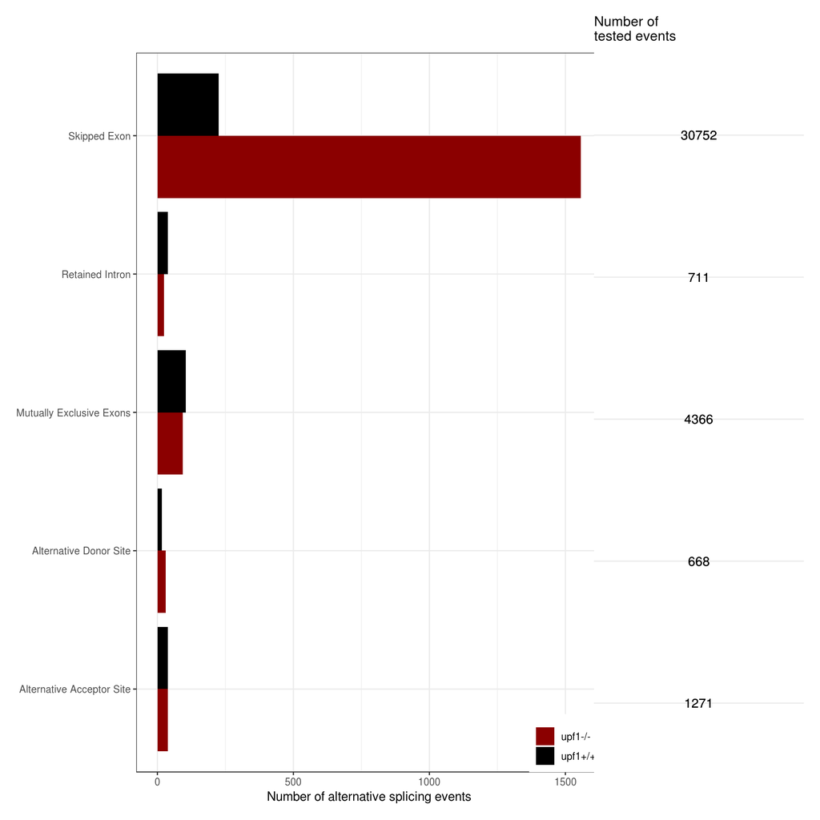

Figure 3B

```r
g.left <- ggplot(data = sumtabL, aes(y = num.sig.events, x = Category, fill = factor(Group.graph))) +
    geom_bar(stat = "identity", position = "dodge") + theme_bw() + theme(axis.title.y = element_blank(),
    plot.margin = unit(c(0.5, 0.4, 0.5, 0.5), units = "cm"), plot.title = element_text(colour = "transparent")) +
    coord_flip() + scale_fill_manual(values = c("dark red", "black")) + scale_y_continuous(name = "Number of alternative splicing events") +
    guides(fill = guide_legend(title = NULL)) + theme(legend.justification = c(1,
    0), legend.position = c(1, 0)) + ggtitle("Number of\ntested events")

g.right <- ggplot(data = sumtabL, aes(y = 1, x = num.tot.events)) + coord_flip() +
    geom_text(aes(label = num.tot.events), fontface = "plain", size = 4) + theme_bw() +
    theme(axis.title.y = element_blank(), panel.grid.minor = element_blank(),
        panel.grid.major = element_line(), axis.text.y = element_blank(), axis.ticks.y = element_blank(),
        axis.text.x = element_text(colour = "transparent"), axis.ticks.x = element_line(colour = "transparent"),
        panel.border = element_rect(colour = "transparent"), plot.margin = unit(c(0.5,
            0.5, 0.5, -0.75), units = "cm"), plot.title = element_text(size = 12),
        axis.title.x = element_text(colour = "transparent")) + ggtitle("Number of\ntested events") +
    scale_y_discrete(name = "Number of alternative splicing events")

g2p <- arrangeGrob(g.left, g.right, ncol = 2, nrow = 1, widths = c(9, 3), heights = c(8))
plot(g2p)
```

#### Figure 3C: Differential splice event stratification in upf1 mutant and wildtype fish

Produce a list of gene IDs with known NMD transcripts as well a list of gene IDs with upregulated nonNMD transcripts in upf1-/- vs upf1+/+ comparison:

```r
NMDlist <- qdat.an$ensembl_gene_id[qdat.an$Biotype2 %in% "NMD"]
nonNMD.up <- res.tab.filt.an$ensembl_gene_id[res.tab.filt.an$Biotype2 %in% "nonNMD" &
    res.tab.filt.an$ChangeDirection %in% "UP"]
```

Perform the calculations:

```r
F3Ctab <- as.data.frame(matrix(ncol = 5, nrow = 5))
colnames(F3Ctab) <- asvo
rownames(F3Ctab) <- c("All recorded events", "Events in PTC+ genes", "Events in PTC- genes",
    "Events in PTC- upregulated genes", "Events in PTC- not upregulated genes")

for (k in seq_along(asvo)) {
    AS.tab.filt <- resL[[asvo[k]]]
    F3Ctab["All recorded events", asvo[k]] <- nrow(AS.tab.filt)
    AS.nonNMD <- AS.tab.filt[!AS.tab.filt$GeneID %in% NMDlist, ]
    F3Ctab["Events in PTC- genes", asvo[k]] <- nrow(AS.nonNMD)
    F3Ctab["Events in PTC+ genes", asvo[k]] <- nrow(AS.tab.filt) - nrow(AS.nonNMD)
    AS.nonNMD.notUP <- AS.nonNMD[!AS.nonNMD$GeneID %in% nonNMD.up, ]
    F3Ctab["Events in PTC- not upregulated genes", asvo[k]] <- nrow(AS.nonNMD.notUP)
    F3Ctab["Events in PTC- upregulated genes", asvo[k]] <- nrow(AS.nonNMD) -
        nrow(AS.nonNMD.notUP)
}
F3Ctab$Total <- rowSums(F3Ctab)
F3Ctab
```

```
##                                        SE RI MXE A5SS A3SS Total
## All recorded events                  1782 62 198   47   76  2165
## Events in PTC+ genes                  159 18  21   18   25   241
## Events in PTC- genes                 1623 44 177   29   51  1924
## Events in PTC- upregulated genes      231 23  37   15   22   328
## Events in PTC- not upregulated genes 1392 21 140   14   29  1596
```

We first stratify the alternative splicing events into two groups, depending if the affected gene has known NMD isoforms or not (events in PTC+, PTC- genes). We then stratify events in PTC- genes into two further groups, depending if the affected genes had upregulated nonNMD transcripts or not (events in PTC- upregulated and not upregulated genes). Note that by pre-substraction of all NMD transcript-encoding genes in the first step, we can substract genes with upregulated nonNMD transcripts in the second step, irrespectively of any of them encoding NMD transcripts as well.

The phrase “upregulated genes” effectively indicates genes coding for upregulated transcipts, as transcript-level quantitation was used.

#### Figure 3F: NMD ratios for selected genes in upf1 mutant and wildtype fish

Prepare plotting data:

```r
plotdata <- qdat.sumW[qdat.sumW$ensembl_gene_id %in% c(bmk$ensembl_gene_id[match(c("srsf7a",
    "srsf5a", "hnrnph3"), bmk$external_gene_name)]), ]
plotdata$GeneSymbol <- bmk$external_gene_name[match(plotdata$ensembl_gene_id,
    bmk$ensembl_gene_id)]
plotdata
```

```
##          ensembl_gene_id   SampleID       NMD    nonNMD      Ratio Group
## 40361 ENSDARG00000029818 HJ028_Mut1 301.18100 267.48063 0.52963130   Mut
## 40362 ENSDARG00000029818 HJ028_Mut2 325.74100 285.85456 0.53260851   Mut
## 40363 ENSDARG00000029818 HJ028_Mut3 300.58400 244.37464 0.55157214   Mut
## 40364 ENSDARG00000029818 HJ028_Mut4 354.17500 271.25824 0.56628746   Mut
## 40365 ENSDARG00000029818  HJ028_WT1   3.99591 261.39578 0.01505665    WT
## 40366 ENSDARG00000029818  HJ028_WT2   3.28812 250.23872 0.01296951    WT
## 40367 ENSDARG00000029818  HJ028_WT3   5.81201 315.59130 0.01808323    WT
## 40368 ENSDARG00000029818  HJ028_WT4   5.11134 300.00099 0.01675232    WT
## 47089 ENSDARG00000035325 HJ028_Mut1  58.24640 180.95724 0.24350131   Mut
## 47090 ENSDARG00000035325 HJ028_Mut2  56.70950 173.71054 0.24611358   Mut
## 47091 ENSDARG00000035325 HJ028_Mut3  58.96350 164.25390 0.26415279   Mut
## 47092 ENSDARG00000035325 HJ028_Mut4  64.47290 177.52854 0.26641535   Mut
## 47093 ENSDARG00000035325  HJ028_WT1   5.40828 106.82202 0.04818913    WT
## 47094 ENSDARG00000035325  HJ028_WT2   5.17945 102.87671 0.04793294    WT
```

[output cut: 35 more lines]

Plot a dotplot with jitter:

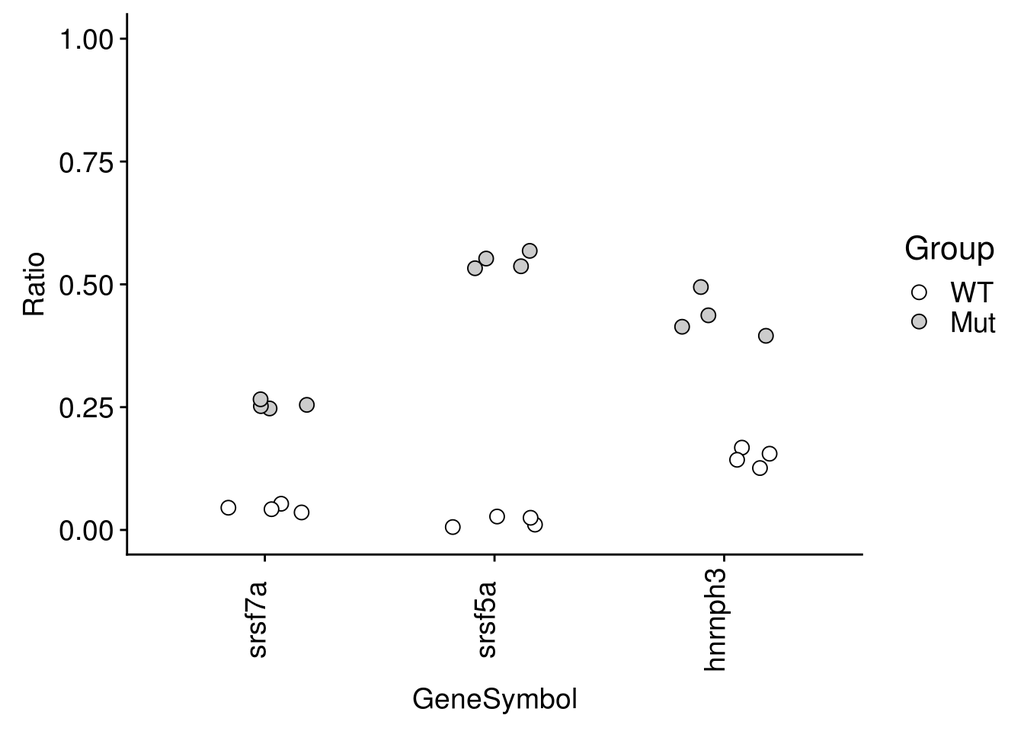

Figure 3F

```r
plotdata$Group <- factor(plotdata$Group, levels = c("WT", "Mut"))
ggplot(data = plotdata, aes(x = reorder(GeneSymbol, Ratio), y = Ratio, fill = Group)) +
    geom_point(position = position_jitter(width = 0.2, height = 0.01, seed = 123),
        size = 3, pch = 21) + scale_fill_manual(values = c("#FFFFFF", "#CCCCCC")) +
    theme(text = element_text(size = 16), axis.text = element_text(size = 14),
        axis.text.x = element_text(angle = 90, vjust = 0), axis.title = element_text(size = 14)) +
    xlab("GeneSymbol") + ylim(0, 1)
```

#### Figure 4A-B: Transcript level quantitation in tnpo3 mutant and wildtype fish with biotype annotation

Load salmon output data with transcript-level TPM counts for tnpo3 mutant and wildtype fish:

```r
con <- curl("https://owncloud.gwdg.de/index.php/s/EaqmwLATYmOiMhw/download",
    open = "rb")
load(con)
close(con)

dim(qdat)
```

```
## [1] 345930      4
```

```r
sum(complete.cases(qdat))
```

```
## [1] 345930
```

```r
## qdat is in a data.table format - make sure the data.table package is
## loaded!
qdat
```

```
##                       Name        TPM   SampleID Group
##      1: ENSDART00000164359 114.297000 Lib_A214_1    WT
##      2: ENSDART00000157701   1.780840 Lib_A214_1    WT
##      3: ENSDART00000158290   0.370952 Lib_A214_1    WT
##      4: ENSDART00000167898 353.155000 Lib_A214_1    WT
##      5: ENSDART00000166393   0.600404 Lib_A214_1    WT
##     ---
## 345926: ENSDART00000166187   0.310205 Lib_A214_9   Mut
## 345927: ENSDART00000168512   7.189190 Lib_A214_9   Mut
## 345928: ENSDART00000171223   2.516670 Lib_A214_9   Mut
## 345929: ENSDART00000163136   3.017370 Lib_A214_9   Mut
## 345930: ENSDART00000165750   2.683170 Lib_A214_9   Mut
```

Load sleuth output data with results of differential transcript expression for tnpo3 mutant and wildtype fish:

```r
con <- curl("https://owncloud.gwdg.de/index.php/s/bnbFKnUJzSrN1SA/download",
    open = "r")
results_table <- read.table(con, sep = "\t", header = TRUE, quote = "", as.is = TRUE)
close(con)

dim(results_table)
```

```
## [1] 57655    13
```

```r
sum(complete.cases(results_table))
```

```
## [1] 48832
```

```r
results_table <- results_table[complete.cases(results_table), ]
dim(results_table)
```

```
## [1] 48832    13
```

```r
head(results_table)
```

```
##            target_id test_stat         pval        qval       rss
## 1 ENSDART00000089689  29.11858 6.808080e-08 0.002653173 32.126533
## 2 ENSDART00000021594  26.44134 2.716634e-07 0.002653173  3.663991
## 3 ENSDART00000005877  26.52204 2.605482e-07 0.002653173  4.431051
## 4 ENSDART00000102416  26.71380 2.359301e-07 0.002653173 10.771936
## 5 ENSDART00000049061  27.72819 1.396131e-07 0.002653173  3.780387
## 6 ENSDART00000067161  23.74839 1.097871e-06 0.008935207  2.043492
##    sigma_sq     tech_var  mean_obs   var_obs sigma_sq_pmax smooth_sigma_sq
## 1 6.4211016 4.205019e-03  5.483655 6.4253067     6.4211016      0.10575640
## 2 0.7327685 2.973498e-05 11.209679 0.7327983     0.7327685      0.01539753
## 3 0.8855597 6.505879e-04  8.105309 0.8862103     0.8855597      0.02272841
## 4 2.1507980 3.589143e-03  7.002063 2.1543871     2.1507980      0.04029769
## 5 0.7557106 3.666948e-04  8.533457 0.7560773     0.7557106      0.01943539
## 6 0.4084207 2.776627e-04  8.797195 0.4086984     0.4084207      0.01795486
##   final_sigma_sq degrees_free
## 1      6.4211016            1
## 2      0.7327685            1
## 3      0.8855597            1
## 4      2.1507980            1
## 5      0.7557106            1
## 6      0.4084207            1
```

Annotate the ‘results_table’ with mean TPM values per group using ‘qdat’ and calculate log2 fold changes:

```r
meandat <- summarize(group_by(qdat, Name, Group), MeanTPM = mean(TPM))
meandatW <- dcast(Name ~ Group, value.var = "MeanTPM", data = meandat)

results_table$MeanTPM.WT <- meandatW$WT[match(results_table$target_id, meandatW$Name)]
results_table$MeanTPM.Mut <- meandatW$Mut[match(results_table$target_id, meandatW$Name)]
results_table$Log2FC <- with(results_table, log2(MeanTPM.Mut/MeanTPM.WT))
sum(is.infinite(results_table$Log2FC))
```

```
## [1] 8
```

We have calculated log2 fold changes on mean TPM values without adding a pseudocount, using only transcripts for which sleuth produced differential expression estimates. This conservative approach doesn’t introduce additional noise when calculating log2 fold changes for lowly expressed genes. As a result, 8 values are infinite, and we will ignore those for further analysis.

Filter results table to retain transcripts with statistical support for differential expression passing the filtering criteria of absolute log2 fold change at least 1, and qvalue less than 0.05:

```r
results_table.filt <- results_table[results_table$qval < 0.05 & abs(results_table$Log2FC) >=
    1, ]
results_table.filt <- results_table.filt[complete.cases(results_table.filt),
    ]
dim(results_table.filt)
```

```
## [1] 170  16
```

This manuscript focuses on the contrast in regulation of NMD and non-NMD transcripts, as defined in ensembl gene annotation http://vega.archive.ensembl.org/info/about/gene_and_transcript_types.html .  
Results reported in the manuscript were annotated using ensembl release 88. Annotate filtered results with transcript biotype using the biomaRt package:

```r
zv10.ens <- useMart(biomart = "ensembl", dataset = "drerio_gene_ensembl", host = "http://mar2017.archive.ensembl.org")
bmk <- getBM(attributes = c("ensembl_transcript_id", "transcript_biotype", "ensembl_gene_id",
    "external_gene_name"), filter = "ensembl_transcript_id", values = results_table.filt$target_id,
    mart = zv10.ens)
res.tab.filt.an <- merge(x = results_table.filt, y = bmk, by.x = "target_id",
    by.y = "ensembl_transcript_id", all.x = TRUE)
head(res.tab.filt.an)
```

```
##            target_id test_stat         pval        qval       rss
## 1 ENSDART00000000392  13.70282 2.141329e-04 0.049156462 1.2640601
## 2 ENSDART00000003035  21.16510 4.213687e-06 0.019111070 4.8550528
## 3 ENSDART00000005547  15.95296 6.493623e-05 0.034997439 2.2976075
## 4 ENSDART00000005877  26.52204 2.605482e-07 0.002653173 4.4310513
## 5 ENSDART00000005895  18.01006 2.197409e-05 0.025195178 0.9610269
## 6 ENSDART00000006549  15.09845 1.020471e-04 0.037986473 1.5011381
##    sigma_sq     tech_var  mean_obs   var_obs sigma_sq_pmax smooth_sigma_sq
## 1 0.2521070 7.049645e-04  7.897974 0.2528120     0.2521070      0.02485657
## 2 0.9709445 6.601209e-05 10.028846 0.9710106     0.9709445      0.01449029
## 3 0.4583599 1.161555e-03  9.817949 0.4595215     0.4583599      0.01474191
## 4 0.8855597 6.505879e-04  8.105309 0.8862103     0.8855597      0.02272841
## 5 0.1921569 4.851279e-05 10.224405 0.1922054     0.1921569      0.01436898
## 6 0.2978310 2.396634e-03  6.800923 0.3002276     0.2978310      0.04546382
##   final_sigma_sq degrees_free MeanTPM.WT MeanTPM.Mut    Log2FC
## 1      0.2521070            1   3.671953    1.441177 -1.349301
## 2      0.9709445            1  95.473600   15.416767 -2.630602
## 3      0.4583599            1  44.725100   12.683633 -1.818117
## 4      0.8855597            1  14.864500    2.510853 -2.565621
## 5      0.1921569            1  60.977300   26.258833 -1.215469
## 6      0.2978310            1   0.614477    1.516773  1.303575
##   transcript_biotype    ensembl_gene_id external_gene_name
## 1     protein_coding ENSDARG00000000380              pde6a
## 2     protein_coding ENSDARG00000013856              amy2a
## 3     protein_coding ENSDARG00000002696              gnb3b
## 4     protein_coding ENSDARG00000030915               cpa1
## 5     protein_coding ENSDARG00000018263              pdia2
## 6     protein_coding ENSDARG00000020289               pif1
```

Annotate ‘qdat’ TPM expression table with transcript biotype information from ensembl:

```r
bmk2 <- getBM(attributes = c("ensembl_transcript_id", "transcript_biotype",
    "ensembl_gene_id", "external_gene_name"), filter = "ensembl_transcript_id",
    values = qdat$Name, mart = zv10.ens)
qdat.an <- unique(merge(x = qdat, y = bmk2, by.x = "Name", by.y = "ensembl_transcript_id",
    all.x = TRUE, allow.cartesian = TRUE))

qdat.an$Biotype2 <- "nonNMD"
qdat.an$Biotype2[qdat.an$transcript_biotype %in% "nonsense_mediated_decay"] <- "NMD"
head(qdat.an)
```

```
##                  Name      TPM   SampleID Group transcript_biotype
## 1: ENSDART00000000004 0.975938 Lib_A214_1    WT     protein_coding
## 2: ENSDART00000000004 1.349600 Lib_A214_2    WT     protein_coding
## 3: ENSDART00000000004 1.375930 Lib_A214_3    WT     protein_coding
## 4: ENSDART00000000004 1.079110 Lib_A214_7   Mut     protein_coding
## 5: ENSDART00000000004 0.861712 Lib_A214_8   Mut     protein_coding
## 6: ENSDART00000000004 1.211880 Lib_A214_9   Mut     protein_coding
##       ensembl_gene_id external_gene_name Biotype2
## 1: ENSDARG00000000001            slc35a5   nonNMD
## 2: ENSDARG00000000001            slc35a5   nonNMD
## 3: ENSDARG00000000001            slc35a5   nonNMD
## 4: ENSDARG00000000001            slc35a5   nonNMD
## 5: ENSDARG00000000001            slc35a5   nonNMD
## 6: ENSDARG00000000001            slc35a5   nonNMD
```

We collapse all transcript isoforms not annotated as “nonsense_mediated_decay” to one category “nonNMD”.

Calculate mean transript expression over replicates in each group and add binarized transcript biotype information:

```r
TPMmean <- as.data.frame(summarize(group_by(qdat.an, Group, Name), MeanTPM = mean(TPM)),
    stringsAsFactors = FALSE)
TPMmean$Biotype <- qdat.an$Biotype2[match(TPMmean$Name, qdat.an$Name)]
head(TPMmean)
```

```
##   Group               Name    MeanTPM Biotype
## 1   Mut ENSDART00000000004  1.0509007  nonNMD
## 2   Mut ENSDART00000000005  3.1270933  nonNMD
## 3   Mut ENSDART00000000042  0.1260707  nonNMD
## 4   Mut ENSDART00000000069 10.0004700  nonNMD
## 5   Mut ENSDART00000000070 11.5042000  nonNMD
## 6   Mut ENSDART00000000087  1.8251867  nonNMD
```

Reshape table to obtain separate columns for the WT and for the Mut group. Add information on passing statistical filters:

```r
TPMmean2 <- dcast(Name + Biotype ~ Group, data = TPMmean, value.var = "MeanTPM")
TPMmean2$Filter <- "Fail"
TPMmean2$Filter[TPMmean2$Name %in% results_table.filt$target_id] <- "Pass"
head(TPMmean2)
```

```
##                 Name Biotype        Mut         WT Filter
## 1 ENSDART00000000004  nonNMD  1.0509007  1.2338227   Fail
## 2 ENSDART00000000005  nonNMD  3.1270933  2.9092200   Fail
## 3 ENSDART00000000042  nonNMD  0.1260707  0.0932793   Fail
## 4 ENSDART00000000069  nonNMD 10.0004700 15.9551000   Fail
## 5 ENSDART00000000070  nonNMD 11.5042000 13.8947667   Fail
## 6 ENSDART00000000087  nonNMD  1.8251867  1.9392467   Fail
```

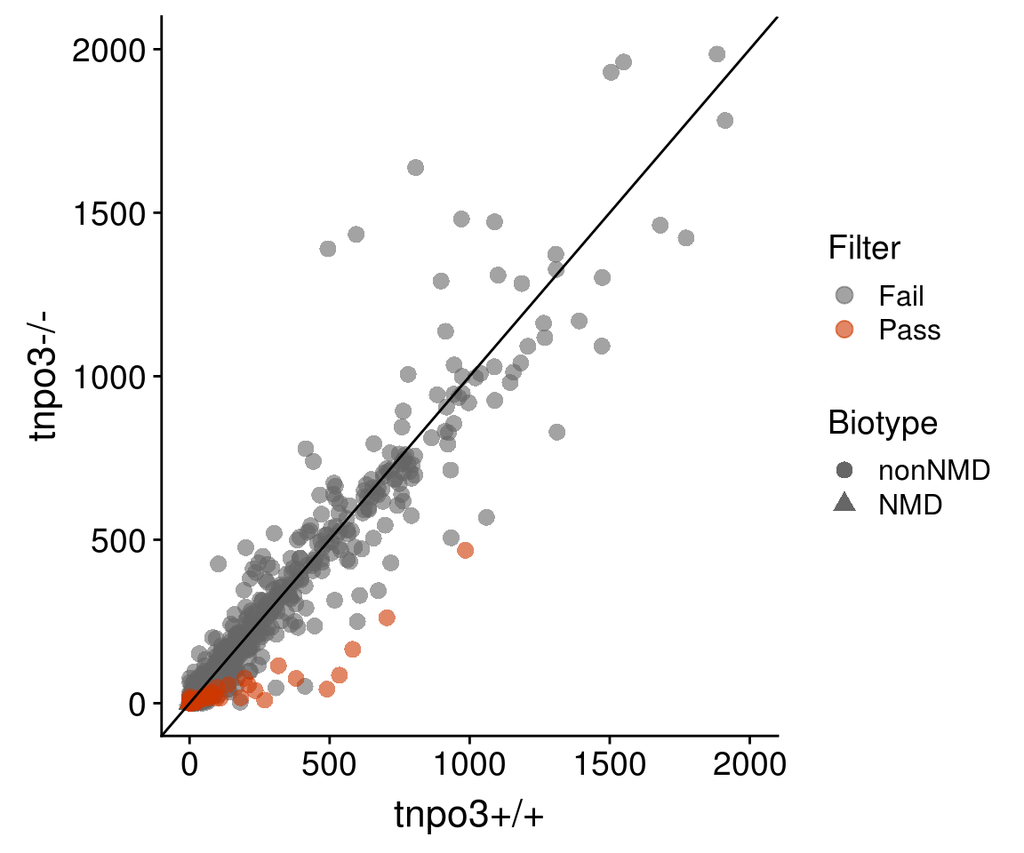

Figure 4A

```r
TPMmean2$Biotype <- factor(TPMmean2$Biotype, levels = c("nonNMD", "NMD"))
TPMmean2$Filter <- factor(TPMmean2$Filter, levels = c("Fail", "Pass"))
ggplot(TPMmean2 %>% arrange(Filter)) + geom_point(aes(x = WT, y = Mut, colour = Filter,
    shape = Biotype), size = 3, alpha = 0.6) + geom_abline(aes(intercept = 0,
    slope = 1)) + theme(axis.text = element_text(size = 14), axis.title = element_text(size = 16),
    strip.text = element_text(size = 12)) + scale_colour_manual(values = c("grey40",
    "orangered3")) + xlab("tnpo3+/+") + ylab("tnpo3-/-") + xlim(0, 2000) + ylim(0,
    2000)
```

Aggregate TPM counts per gene as sum over transcript counts, separately for “NMD” and for “nonNMD” transcript classes:

```r
qdat.sum <- summarize(group_by(qdat.an, ensembl_gene_id, SampleID, Biotype2),
    sumTPM = sum(TPM))
qdat.sumW <- dcast(ensembl_gene_id + SampleID ~ Biotype2, value.var = "sumTPM",
    data = qdat.sum)
qdat.sumW <- qdat.sumW[complete.cases(qdat.sumW), ]
dim(qdat.sumW)
```

```
## [1] 3552    4
```

```r
head(qdat.sumW)
```

```
##        ensembl_gene_id   SampleID       NMD   nonNMD
## 295 ENSDARG00000000747 Lib_A214_1 0.1661250 0.771244
## 296 ENSDARG00000000747 Lib_A214_2 0.2217820 0.726916
## 297 ENSDARG00000000747 Lib_A214_3 0.1212330 0.829341
## 298 ENSDARG00000000747 Lib_A214_7 0.0367822 0.907384
## 299 ENSDARG00000000747 Lib_A214_8 0.0268508 0.774460
## 300 ENSDARG00000000747 Lib_A214_9 0.1268680 0.488939
```

Calculate mean fraction of “NMD” transcript expression against sum of “NMD” and “nonNMD” transcript expression per gene (“NMD ratio”):

```r
qdat.sumW$Ratio <- with(qdat.sumW, NMD/(NMD + nonNMD))
qdat.sumW$Group <- qdat$Group[match(qdat.sumW$SampleID, qdat$SampleID)]
qdat.sum2 <- summarize(group_by(qdat.sumW, ensembl_gene_id, Group), MeanRatio = mean(Ratio))
qdat.sum2W <- dcast(ensembl_gene_id ~ Group, value.var = "MeanRatio", data = qdat.sum2)
dim(qdat.sum2W)
```

```
## [1] 592   3
```

```r
head(qdat.sum2W)
```

```
##      ensembl_gene_id        Mut          WT
## 1 ENSDARG00000000747 0.09282834 0.179512174
## 2 ENSDARG00000001169 0.08334426 0.019012728
## 3 ENSDARG00000001244 0.09408309 0.019285831
## 4 ENSDARG00000002487 0.01107931 0.009824942
## 5 ENSDARG00000002549 0.17749292 0.054349998
## 6 ENSDARG00000002710 0.00162929 0.004365954
```

Apply limma to logit-transformed NMD ratios to obtain a list of statistically different ratios between mutant and wildtype fish, and filter results for FDR<0.05:

```r
qdat.sumW$LogitRatio <- logit(qdat.sumW$Ratio, percents = FALSE, adjust = 0.025)

limdat <- dcast(ensembl_gene_id ~ SampleID, value.var = "LogitRatio", data = qdat.sumW)
rownames(limdat) <- limdat$ensembl_gene_id
limdat <- limdat[, !colnames(limdat) %in% "ensembl_gene_id"]

sampleInfo <- unique(qdat.sumW[, c("SampleID", "Group")])
rownames(sampleInfo) <- sampleInfo$SampleID
sampleInfo <- sampleInfo[match(colnames(limdat), sampleInfo$SampleID), ]

# limma
design <- as.data.frame(matrix(ncol = 2, nrow = (ncol(limdat))), stringsAsFactors = FALSE)
colnames(design) <- c("Intercept", "Group")
rownames(design) <- colnames(limdat)
design$Group <- as.numeric(factor(sampleInfo$Group[match(colnames(limdat), sampleInfo$SampleID)],
    levels = c("WT", "Mut")))

design$Intercept <- 1
design <- as.matrix(design)

fit <- lmFit(limdat, design)
fit.eB <- eBayes(fit)
tT.FDR5 <- topTable(fit.eB, 2, p.value = 0.05, number = Inf)[, c("logFC", "t",
    "adj.P.Val", "B")]
dim(tT.FDR5)
```

```
## [1] 1 4
```

```r
head(tT.FDR5)
```

```
##                        logFC         t  adj.P.Val        B
## ENSDARG00000007863 -1.159126 -12.01336 0.03629671 2.178589
```

Add information on passing or failing filters on statistical metrics:

```r
qdat.sum2W$Filter <- "FAIL"
qdat.sum2W$Filter[qdat.sum2W$ensembl_gene_id %in% rownames(tT.FDR5)] <- "PASS"
table(qdat.sum2W$Filter)
```

```
##
## FAIL PASS
##  591    1
```

Plot NMD ratios per gene aggregated over wild type and mutant groups:

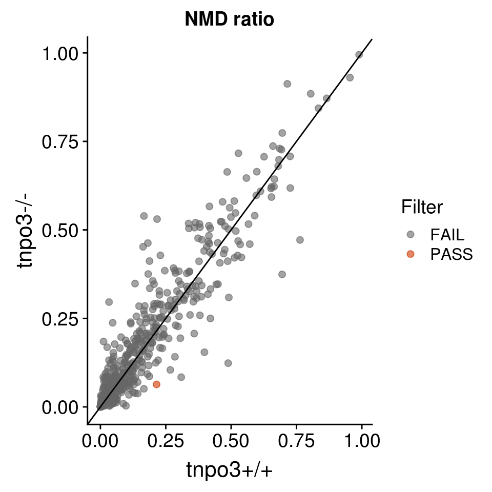

Figure 4B left panel

```r
ggplot(qdat.sum2W %>% arrange(Filter)) + geom_point(aes(x = WT, y = Mut, colour = Filter),
    size = 2, alpha = 0.6) + geom_abline(aes(intercept = 0, slope = 1)) + scale_colour_manual(values = c("grey40",
    "orangered3")) + theme(axis.text = element_text(size = 14), axis.title = element_text(size = 16),
    strip.text = element_text(size = 12)) + ggtitle("NMD ratio") + xlab("tnpo3+/+") +
    ylab("tnpo3-/-")
```

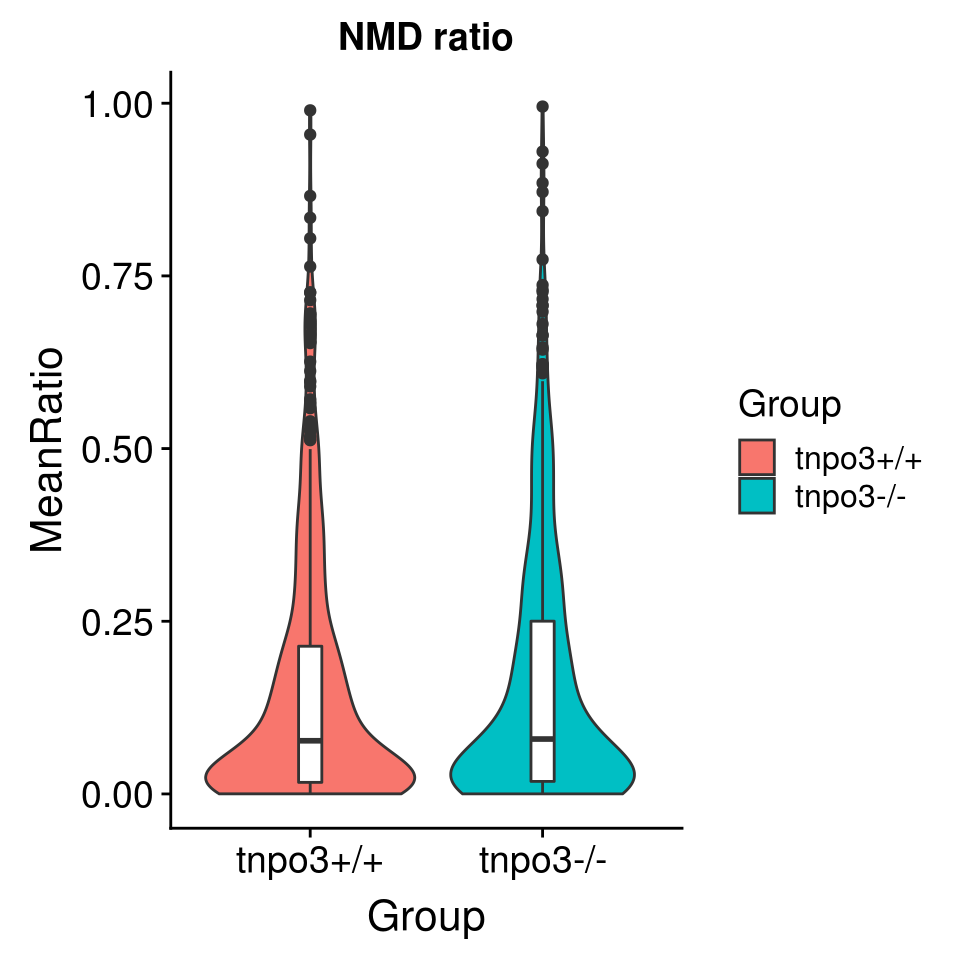

Figure 4B right panel

```r
qdat.sum2$Group[qdat.sum2$Group %in% "WT"] <- "tnpo3+/+"
qdat.sum2$Group[qdat.sum2$Group %in% "Mut"] <- "tnpo3-/-"
qdat.sum2$Group <- factor(qdat.sum2$Group, levels = c("tnpo3+/+", "tnpo3-/-"))
ggplot(data = qdat.sum2) + geom_violin(aes(x = Group, y = MeanRatio, fill = Group)) +
    geom_boxplot(aes(x = Group, y = MeanRatio), width = 0.1) + ggtitle("NMD ratio") +
    theme(axis.text = element_text(size = 14), axis.title = element_text(size = 16))
```

#### Figure 4C: Differential splicing event detection in tnpo3 mutant and wildtype fish

Download event tables, one for each alternative event class (SE, RI, MXE, A5SS, A3SS), and filter for FDR<0.01 and absolute inclusion level difference of 0.05:

```r
asv <- c("A3SS", "A5SS", "MXE", "RI", "SE")
resL <- vector("list", length(asv))
names(resL) <- asv
conL <- list("https://owncloud.gwdg.de/index.php/s/iuKZhNHtnA6xRqi/download",
    "https://owncloud.gwdg.de/index.php/s/ZZ1uwNHxQ7Aiydy/download", "https://owncloud.gwdg.de/index.php/s/8qOyBxHs4Sldj3W/download",
    "https://owncloud.gwdg.de/index.php/s/KDc9m65IRwEUlKd/download", "https://owncloud.gwdg.de/index.php/s/BipXuUaEOfsq3tp/download")
names(conL) <- asv

for (i in seq_along(asv)) {
    con <- curl(conL[[i]], open = "r")
    tabi <- read.table(con, sep = "\t", header = TRUE, quote = "", as.is = TRUE)
    close(con)
    tabi$GeneID <- with(tabi, gsub("\"", "", GeneID))
    tabi$geneSymbol <- with(tabi, gsub("\"", "", geneSymbol))
    tabi_f <- tabi[tabi$FDR < 0.01 & abs(tabi$IncLevelDifference) >= 0.05, ]
    resL[[i]] <- tabi_f
}
unlist(lapply(resL, function(X) nrow(X)))
```

```
## A3SS A5SS  MXE   RI   SE
##   90   73  215  103 2345
```

```r
unlist(lapply(resL, function(X) length(unique(X$GeneID))))
```

```
## A3SS A5SS  MXE   RI   SE
##   88   72  189   97 1887
```

```r
tnpo3_resL <- resL
```

Download the summary table for rMATS events :

```r
con <- curl("https://owncloud.gwdg.de/index.php/s/fDsyi2bm2hyCwqm/download",
    open = "r")
sumtab <- read.table(con, sep = "\t", header = TRUE, quote = "", as.is = TRUE)
close(con)
sumtab
```

```
##   EventType NumEvents.JC.only SigEvents.JC.only NumEvents.JC.readsOnTarget
## 1        SE             30438   3938 (558:3380)                      30568
## 2       MXE              3595     396 (167:229)                       3605
## 3      A5SS               693       123 (39:84)                        694
## 4      A3SS              1320      184 (61:123)                       1320
## 5        RI               687      243 (60:183)                        687
##   SigEvents.JC.readsOnTarget
## 1            3892 (545:3347)
## 2              309 (135:174)
## 3                127 (40:87)
## 4               188 (61:127)
## 5               248 (56:192)
```

Update information using event counts from tables filtered according to chosen criteria and format for plotting:

```r
asvo <- c("SE", "RI", "MXE", "A5SS", "A3SS")
sumtab <- sumtab[match(c(asvo), sumtab$EventType), ]
sumtab$LYlab <- c("Skipped Exon", "Retained Intron", "Mutually Exclusive Exons",
    "Alternative Donor Site", "Alternative Acceptor Site")
sumtab$RYlab <- sumtab$NumEvents.JC.only
sumtab$WT <- NA
sumtab$MT <- NA
for (k in seq_along(asvo)) {
    tab.filt <- resL[[asvo[k]]]
    # at first, keep the same direction as in the original rMATS ouput
    sumtab$WT[sumtab$EventType == asvo[k]] <- nrow(tab.filt[tab.filt$IncLevelDifference <
        0, ])
    sumtab$MT[sumtab$EventType == asvo[k]] <- nrow(tab.filt[tab.filt$IncLevelDifference >
        0, ])
}
# DO reverse the numbers for SE (to actually reflect number of skipping
# events, rather than retention)
sumtab[sumtab$EventType == "SE", c("WT", "MT")] <- rev(sumtab[sumtab$EventType ==
    "SE", c("WT", "MT")])
sumtab
```

```
##   EventType NumEvents.JC.only SigEvents.JC.only NumEvents.JC.readsOnTarget
## 1        SE             30438   3938 (558:3380)                      30568
## 5        RI               687      243 (60:183)                        687
## 2       MXE              3595     396 (167:229)                       3605
## 3      A5SS               693       123 (39:84)                        694
## 4      A3SS              1320      184 (61:123)                       1320
##   SigEvents.JC.readsOnTarget                     LYlab RYlab  WT   MT
## 1            3892 (545:3347)              Skipped Exon 30438 313 2032
## 5               248 (56:192)           Retained Intron   687  79   24
## 2              309 (135:174)  Mutually Exclusive Exons  3595 129   86
## 3                127 (40:87)    Alternative Donor Site   693  54   19
## 4               188 (61:127) Alternative Acceptor Site  1320  60   30
```

```r
sumtabL <- melt(sumtab[, 6:9], variable.name = "Group", value.name = "num.sig.events",
    id.var = c("LYlab", "RYlab"))
colnames(sumtabL)[1:2] <- c("Category", "num.tot.events")
sumtabL$num.sig.events <- as.numeric(sumtabL$num.sig.events)
sumtabL$num.tot.events <- as.character(sumtabL$num.tot.events)
sumtabL$num.tot.events <- factor(sumtabL$num.tot.events, levels = rev(as.character(sumtabL$num.tot.events[1:5])))
Glab <- c(WT = "tnpo3+/+", MT = "tnpo3-/-")
sumtabL$Group.graph <- Glab[sumtabL$Group]
sumtabL
```

```
##                     Category num.tot.events Group num.sig.events
## 1               Skipped Exon          30438    WT            313
## 2            Retained Intron            687    WT             79
## 3   Mutually Exclusive Exons           3595    WT            129
## 4     Alternative Donor Site            693    WT             54
## 5  Alternative Acceptor Site           1320    WT             60
## 6               Skipped Exon          30438    MT           2032
## 7            Retained Intron            687    MT             24
## 8   Mutually Exclusive Exons           3595    MT             86
## 9     Alternative Donor Site            693    MT             19
## 10 Alternative Acceptor Site           1320    MT             30
##    Group.graph
## 1     tnpo3+/+
## 2     tnpo3+/+
## 3     tnpo3+/+
## 4     tnpo3+/+
## 5     tnpo3+/+
## 6     tnpo3-/-
## 7     tnpo3-/-
## 8     tnpo3-/-
## 9     tnpo3-/-
## 10    tnpo3-/-
```

rMATS reports a skipped exon as an event in the sample group, in which the inclusion ratio for that exon is higher, such that it is effectively an exon retention event. In order to be able to interpret the reported events as proper exon skipping, we have reverted the number of reported exon retention events between the experimental groups in the code chunk above. As a result, exons with lower inclusion levels in the mutant group are now reported as skipped exons in that group, and exons with lower inclusion levels in the wildtype groups are reported as skipped in that group.

Generate the final plot by combining two plot grobs:

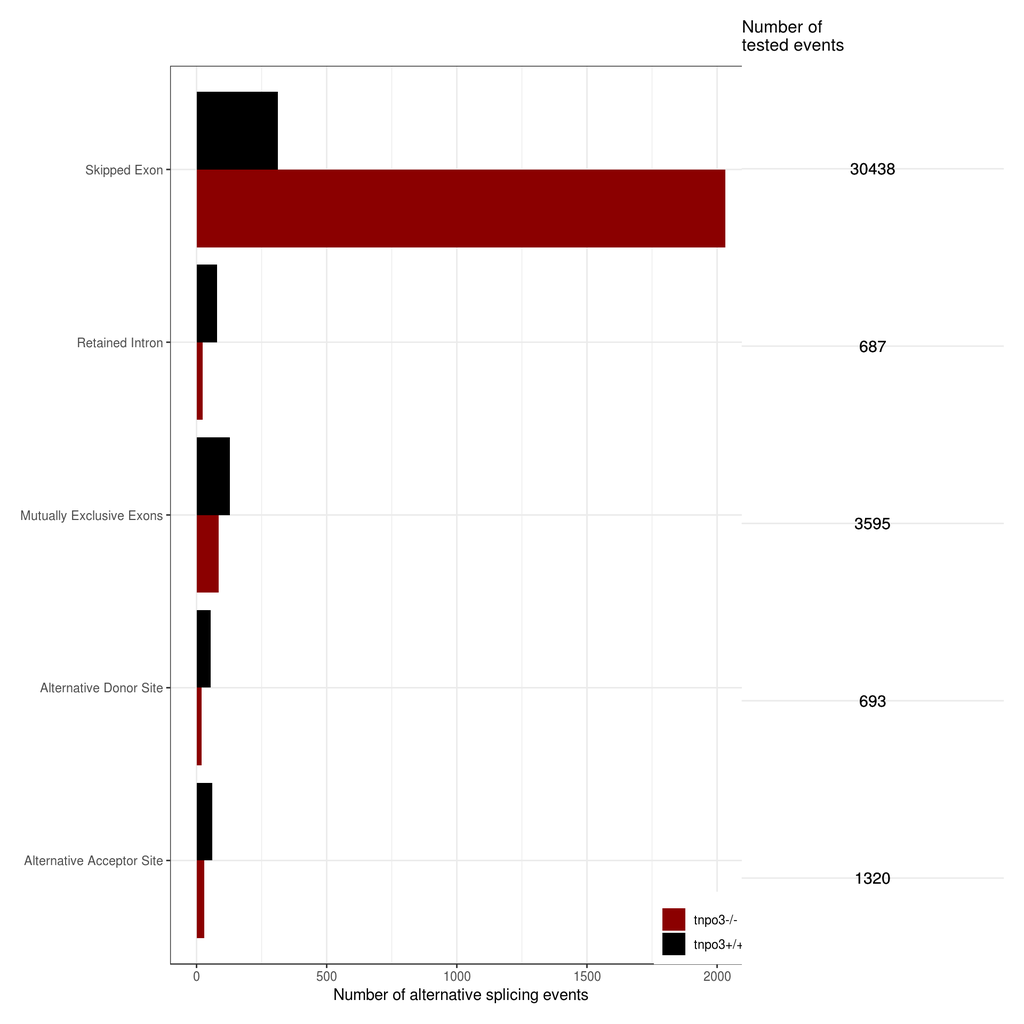

Figure 4C

```r
g.left <- ggplot(data = sumtabL, aes(y = num.sig.events, x = Category, fill = factor(Group.graph))) +
    geom_bar(stat = "identity", position = "dodge") + theme_bw() + theme(axis.title.y = element_blank(),
    plot.margin = unit(c(0.5, 0.4, 0.5, 0.5), units = "cm"), plot.title = element_text(colour = "transparent")) +
    coord_flip() + scale_fill_manual(values = c("dark red", "black")) + scale_y_continuous(name = "Number of alternative splicing events") +
    guides(fill = guide_legend(title = NULL)) + theme(legend.justification = c(1,
    0), legend.position = c(1, 0)) + ggtitle("Number of\ntested events")

g.right <- ggplot(data = sumtabL, aes(y = 1, x = num.tot.events)) + coord_flip() +
    geom_text(aes(label = num.tot.events), fontface = "plain", size = 4) + theme_bw() +
    theme(axis.title.y = element_blank(), panel.grid.minor = element_blank(),
        panel.grid.major = element_line(), axis.text.y = element_blank(), axis.ticks.y = element_blank(),
        axis.text.x = element_text(colour = "transparent"), axis.ticks.x = element_line(colour = "transparent"),
        panel.border = element_rect(colour = "transparent"), plot.margin = unit(c(0.5,
            0.5, 0.5, -0.75), units = "cm"), plot.title = element_text(size = 12),
        axis.title.x = element_text(colour = "transparent")) + ggtitle("Number of\ntested events") +
    scale_y_discrete(name = "Number of alternative splicing events")

g2p <- arrangeGrob(g.left, g.right, ncol = 2, nrow = 1, widths = c(9, 3), heights = c(8))
plot(g2p)
```

#### Figure 4D: Comparison of genes affected by differential splicing events between upf1 mutant and tnpo3 mutant fish

Generate strings identifying unique events for different classes of events. For each class , intersect the unique identifiers:

```r
sl <- vector("list", length(asvo))
names(sl) <- asvo
sl[["SE"]] <- c("chr", "strand", "exonStart_0base", "exonEnd")
sl[["RI"]] <- c("chr", "strand", "riExonStart_0base", "riExonEnd")
sl[["MXE"]] <- c("chr", "strand", "X1stExonStart_0base", "X1stExonEnd", "X2ndExonStart_0base",
    "X2ndExonEnd")
sl[["A3SS"]] <- c("chr", "strand", "longExonStart_0base", "longExonEnd", "shortES",
    "shortEE")
sl[["A5SS"]] <- c("chr", "strand", "longExonStart_0base", "longExonEnd", "shortES",
    "shortEE")

for (i in seq_along(sl)) {
    a <- asvo[i]
    ud <- upf1_resL[[a]]
    td <- tnpo3_resL[[a]]
    s <- sl[[a]]
    u <- apply(ud[, s], 1, function(X) paste(X, collapse = "_"))
    t <- apply(td[, s], 1, function(X) paste(X, collapse = "_"))

    message(sprintf("There are %s common %s events between upf1 and tnpo3 sets. ",
        length(intersect(u, t)), a))
    message(sprintf("There are %s unique %s events in the upf1 set.", length(setdiff(u,
        t)), a))
    message(sprintf("There are %s unique %s events in the tnpo3 set.", length(setdiff(t,
        u)), a))
}
```

```
## There are 318 common SE events between upf1 and tnpo3 sets.
```

```
## There are 1409 unique SE events in the upf1 set.
```

```
## There are 1953 unique SE events in the tnpo3 set.
```

```
## There are 20 common RI events between upf1 and tnpo3 sets.
```

```
## There are 34 unique RI events in the upf1 set.
```

```
## There are 78 unique RI events in the tnpo3 set.
```

```
## There are 16 common MXE events between upf1 and tnpo3 sets.
```

```
## There are 173 unique MXE events in the upf1 set.
```

```
## There are 195 unique MXE events in the tnpo3 set.
```

```
## There are 6 common A5SS events between upf1 and tnpo3 sets.
```

```
## There are 41 unique A5SS events in the upf1 set.
```

```
## There are 67 unique A5SS events in the tnpo3 set.
```

```
## There are 14 common A3SS events between upf1 and tnpo3 sets.
```

```
## There are 61 unique A3SS events in the upf1 set.
```

```
## There are 74 unique A3SS events in the tnpo3 set.
```

#### Figure 5C NMD ratio for rpl10a and rpl22l1 genes in upf1 wild type and mutant fish

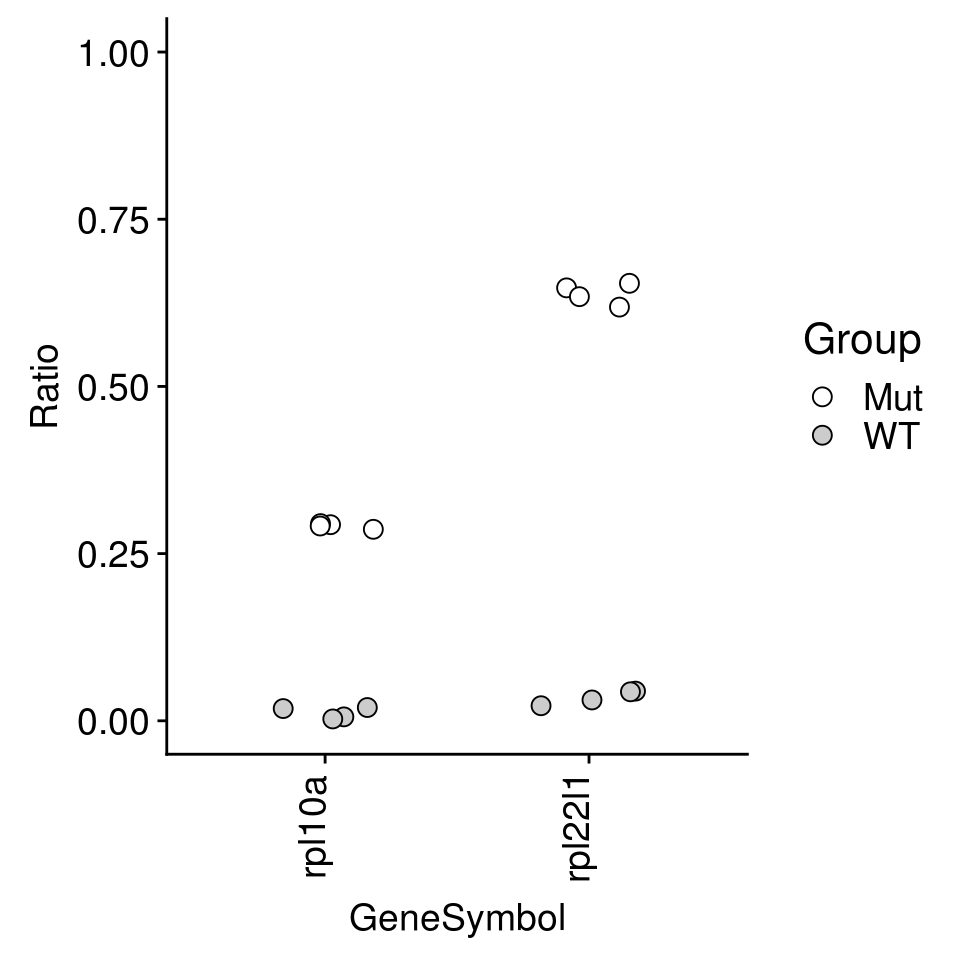

Figure 5C

```r
plotdata <- upf1_qdat.sumW[upf1_qdat.sumW$ensembl_gene_id %in% unique(bmk2$ensembl_gene_id[bmk2$external_gene_name %in%
    c("rpl10a", "rpl22l1")]), ]
plotdata$GeneSymbol <- bmk2$external_gene_name[match(plotdata$ensembl_gene_id,
    bmk2$ensembl_gene_id)]
ggplot(data = plotdata, aes(x = reorder(GeneSymbol, Ratio), y = Ratio, fill = Group)) +
    geom_point(position = position_jitter(width = 0.2, height = 0.01, seed = 123),
        size = 3, pch = 21) + scale_fill_manual(values = c("#FFFFFF", "#CCCCCC")) +
    theme(text = element_text(size = 16), axis.text = element_text(size = 14),
        axis.text.x = element_text(angle = 90, vjust = 0), axis.title = element_text(size = 14)) +
    xlab("GeneSymbol") + ylim(0, 1)
```

#### Session Info

Time needed to execute the R code in this document:

```r
end_time <- Sys.time()
end_time - start_time
```

```
## Time difference of 11.67527 mins
```